# Lab 2: Sentiment Analysis I

Maxwwell Patterson

2024-04-16

## Assignment (Due 4/16 by 11:59 PM)

### Obtain your data and load it into R

- Access the Nexis Uni database through the UCSB library: https://www.library.ucsb.edu/research/db/211
- Choose a key search term or terms to define a set of articles.

My key words are “Kern” and “oil”!

- Use your search term along with appropriate filters to obtain and download a batch of at least 100 full text search results (.docx). You are limited to downloading 100 articles at a time, so if you have more results than that, you have to download them in batches (rows 1-100, 101-200, 201-300 etc.)

```
Guidance for {LexisNexisTools} : <https://github.com/JBGruber/LexisNexisTools/wiki/Downloading-Files-From-Nexis>
```

- Read your Nexis article documents into RStudio.

```r
setwd("/Users/maxwellpatterson/Desktop/classes/spring/eds231/eds231-materials/Nexis/kern_oil_news")

# Reading in docx files
post_files <- list.files(pattern = ".docx",
                         path = getwd(),
                         full.names = TRUE,
                         recursive = TRUE,
                         ignore.case = TRUE)

# Use LNT to handle docs
dat <- lnt_read(post_files)
```

[output not shown]

[output not shown]

[output not shown]

[output not shown]

[output not shown]

[output not shown]

[output not shown]

[output not shown]

[output not shown]

[output not shown]

[output not shown]

[output not shown]

[output not shown]

[output not shown]

[output not shown]

```r
meta_df <- dat@meta
articles_df <- dat@articles
paragraphs_df <- dat@paragraphs

dat2 <- tibble(Date=meta_df$Date, Headline = meta_df$Headline, id = articles_df$ID, text = articles_df$Article)
```

- Use the full text of the articles for the analysis. Inspect the data (in particular the full-text article data).
- If necessary, clean any artifacts of the data collection process (hint: this type of thing should be removed: “Apr 04, 2022( Biofuels Digest: http://www.biofuelsdigest.com/Delivered by Newstex”) and any other urls)
- Remove any clear duplicate articles. LNT has a method for this, but it doesn’t seem to work, so you probably need to do it manually.

```r
# Cleaning up data
dat2 <- dat2 %>%
  dplyr::filter(!is.na(Headline))
```

### Explore your data and conduct the following analyses:

```r
# Load bing sentiment lexicon from tidytext
bing_sent <- get_sentiments("bing")
head(bing_sent)
```

```
## # A tibble: 6 × 2
##   word       sentiment
##   <chr>      <chr>
## 1 2-faces    negative
## 2 abnormal   negative
## 3 abolish    negative
## 4 abominable negative
## 5 abominably negative
## 6 abominate  negative
```

```r
# Score words using wing lexicon
text_words <- dat2 %>%
  unnest_tokens(output=word, input=text, token='words')

sent_words <- text_words %>%
  anti_join(stop_words, by='word') %>%
  inner_join(bing_sent, by='word') %>%
  mutate(sent_num = case_when(sentiment =='negative'~-1,
                              sentiment =='positive'~1))
```

1. Calculate mean sentiment across all your articles

```r
sent_article <- sent_words %>%
  group_by(Headline) %>%
  count(id, sentiment) %>%
  pivot_wider(names_from = sentiment, values_from=n)%>%
  mutate(polarity = positive-negative)

mean_sent <- mean(sent_article$polarity, na.rm = T)

paste0("Mean sentiment across all articles: ", mean_sent)
```

```
## [1] "Mean sentiment across all articles: -8.4014598540146"
```

2. Sentiment by article plot. The one provided in class needs significant improvement.

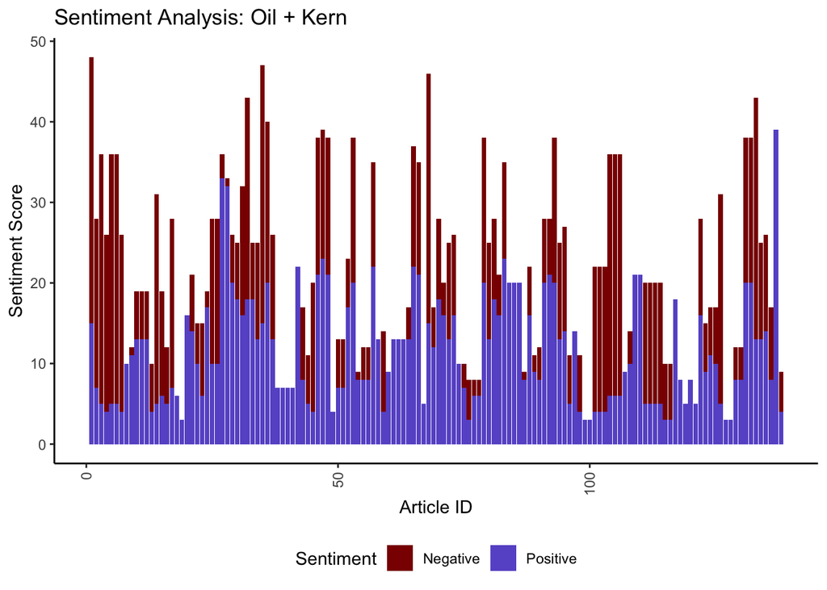

```r
ggplot(sent_article, aes(x = id)) +
  geom_col(aes(y = negative, fill = "Negative"), position = "identity", show.legend = TRUE) +
  geom_col(aes(y = positive, fill = "Positive"), position = "identity", show.legend = TRUE) +
  scale_fill_manual(values = c("Negative" = "red4", "Positive" = "slateblue3"), name = "Sentiment") +
  labs(
    title = "Sentiment Analysis: Oil + Kern",
    x = "Article ID",
    y = "Sentiment Score"
  ) +
  theme_classic() +
  theme(
    legend.position = "bottom",
    axis.text.x = element_text(angle = 90, vjust = 0.5, hjust = 1)
  )
```

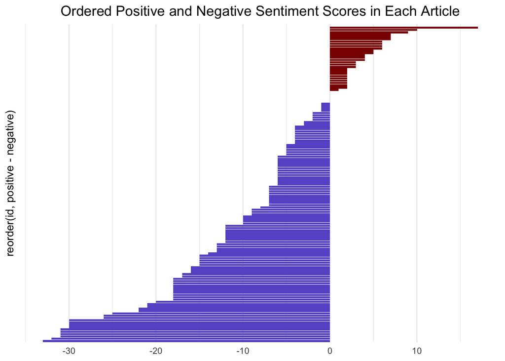

```r
ggplot(sent_article, aes(x = reorder(id, positive - negative), y = positive - negative)) +
  geom_col(aes(fill = ifelse(positive - negative > 0, "slateblue3", "red4"))) +
  scale_fill_manual(values = c("slateblue3", "red4"), guide = "none") +
  coord_flip() +
  theme_minimal() +
  theme(
    panel.grid.major.y = element_blank(),
    panel.grid.minor.y = element_blank(),
    axis.text.y = element_blank(),
    axis.ticks.y = element_blank(),
    axis.title.x = element_blank(),
    plot.title = element_text(size = 14, hjust = 0.5)
  ) +
  labs(
    title = "Ordered Positive and Negative Sentiment Scores in Each Article"
  )
```

3. Most common nrc emotion words and plot by emotion

```r
# Get most common nrc emotion words
nrc_sent <- get_sentiments('nrc')
nrc_word_counts <- text_words %>%
  anti_join(stop_words, by='word') %>%
  inner_join(nrc_sent) %>%
  count(word, sentiment, sort=T)
nrc_word_counts
```

```
## # A tibble: 2,085 × 3
##    word      sentiment        n
##    <chr>     <chr>        <int>
##  1 county    trust         1206
##  2 kern      negative       857
##  3 court     anger          504
##  4 court     anticipation   504
##  5 court     fear           504
##  6 ordinance trust          298
##  7 public    anticipation   294
##  8 public    positive       294
##  9 resources joy            168
## 10 resources positive       168
## # ℹ 2,075 more rows
```

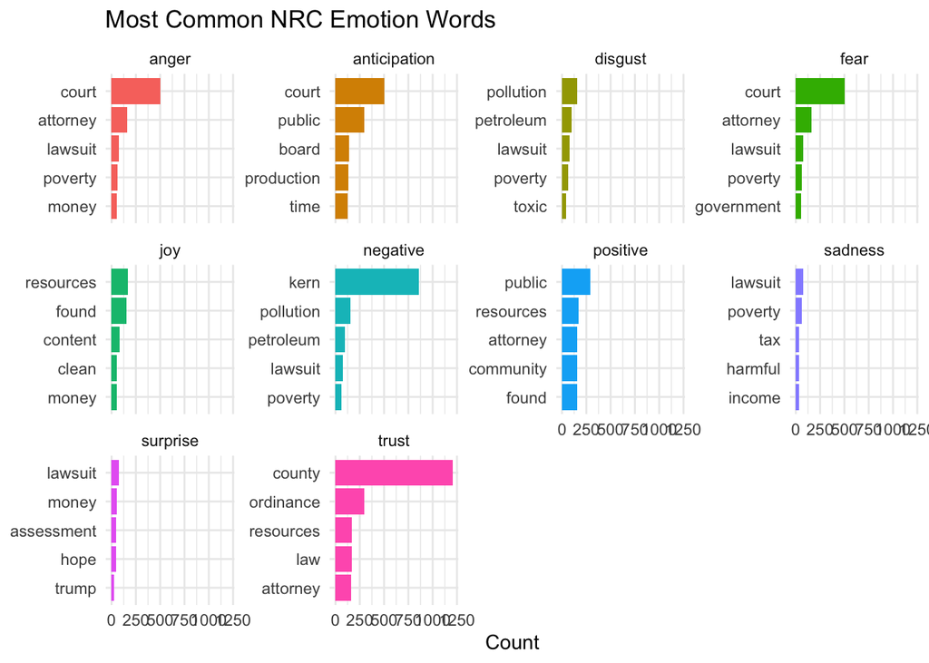

```r
# Plot by emotion
nrc_word_counts %>%
  group_by(sentiment) %>%
  slice_max(n, n = 5) %>%
  ungroup() %>%
  mutate(word = reorder(word, n)) %>%
  ggplot(aes(n, word, fill = sentiment)) +
  geom_col(show.legend = FALSE) +
  facet_wrap(~sentiment, scales = "free_y") +
  labs(x = 'Count', y = NULL, title = "Most Common NRC Emotion Words") +
  theme_minimal()
```

4. Look at the nrc contribution to emotion by word plots. Identify and reclassify or remove at least one term that gives misleading results in your context.

```r
misleading_words <- c("court", "kern", "attorney", "public", "county")
nrc_word_counts_new <- nrc_word_counts %>%
  dplyr::filter(!word %in% misleading_words)
```

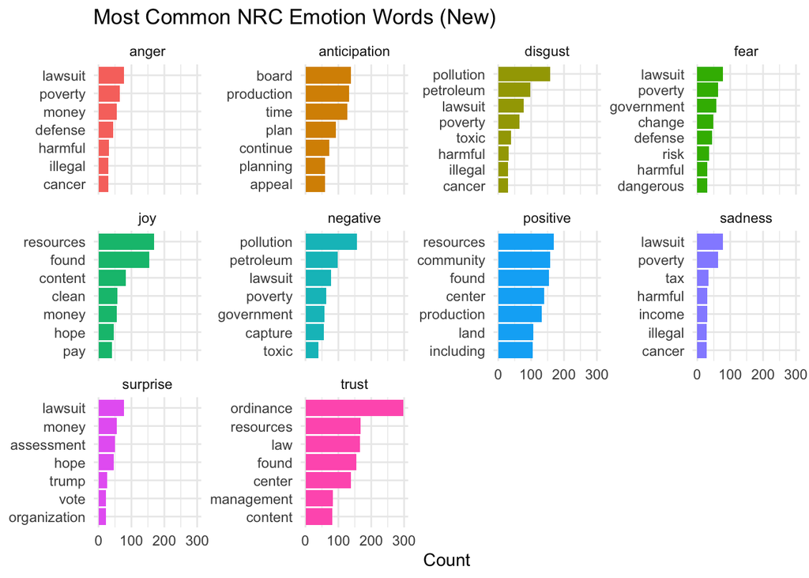

```r
nrc_word_counts_new %>%
  group_by(sentiment) %>%
  slice_max(n, n = 7) %>%
  ungroup() %>%
  mutate(word = reorder(word, n)) %>%
  ggplot(aes(n, word, fill = sentiment)) +
  geom_col(show.legend = FALSE) +
  facet_wrap(~sentiment, scales = "free_y") +
  labs(x = 'Count', y = NULL, title = "Most Common NRC Emotion Words (New)") +
  theme_minimal()
```

5. Plot the amount of nrc emotion words as a percentage of all the emotion words used each day (aggregate text from articles published on the same day). How does the distribution of emotion words change over time? Can you think of any reason this would be the case?

```r
daily_emotions <- sent_words %>%
  inner_join(nrc_sent %>% rename(em_sentiment = sentiment), by = 'word') %>%
  group_by(Date, em_sentiment) %>%
  summarise(count = n()) %>%
  mutate(total = sum(count)) %>%
  group_by(Date) %>%
  mutate(percentage = count / total * 100) %>%
  ungroup() %>%
  pivot_wider(names_from = em_sentiment, values_from = percentage, values_fill = 0)
```

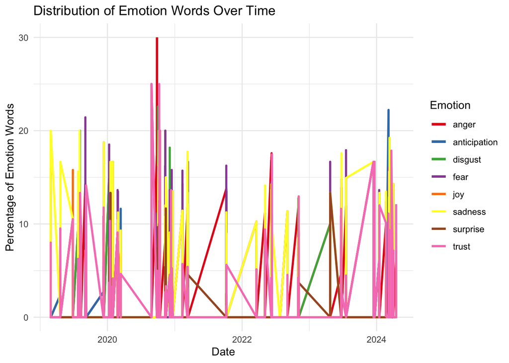

```r
ggplot(daily_emotions, aes(x = Date)) +
  geom_line(aes(y = anger, color = "anger"), size = 1) +
  geom_line(aes(y = anticipation, color = "anticipation"), size = 1) +
  geom_line(aes(y = disgust, color = "disgust"), size = 1) +
  geom_line(aes(y = fear, color = "fear"), size = 1) +
  geom_line(aes(y = joy, color = "joy"), size = 1) +
  geom_line(aes(y = sadness, color = "sadness"), size = 1) +
  geom_line(aes(y = surprise, color = "surprise"), size = 1) +
  geom_line(aes(y = trust, color = "trust"), size = 1) +
  scale_color_manual(name = "Emotion", values = brewer.pal(8, "Set1")) +
  labs(
    x = "Date",
    y = "Percentage of Emotion Words",
    title = "Distribution of Emotion Words Over Time"
  ) +
  theme_minimal()
```

It seems like there were significant events at the end of 2020/start of 2021. This is reflected by the high levels of anger, but also the high levels of trust are worth investigating. It seems like the words that are associated with trust are related to legal concepts, so they may not in fact be as interesting or informative as the more typical understanding of trust in an interpersonal kind of context. These spikes are likely due to ceratin policy additions or reactions to new policies.